# Задачи по Эконометрике-2: logit/probit-модель

Н.В. Артамонов (МГИМО МИД России)

# 1 Нормальное и логистическое распределение

Плотность стандартного N(0,1) гауссова распределения $\phi(t)=\frac{1}{\sqrt{2\pi}}\exp(-t^2/2)$ ($t\in\mathbb{R}$). Функция стандартного нормального распределения $\Phi(x)=\int_{-\infty}^x \phi(t)dt$ ($x\in\mathbb{R}$).

Функция логистического распределения $\Lambda(x)=\frac{\exp(x)}{1+\exp(x)}$ ($x\in\mathbb{R}$). Плотность логистического распределения $\lambda(x)=\Lambda'(x)=\frac{\exp(x)}{(1+\exp(x))^2}$

Плотности на одном графике

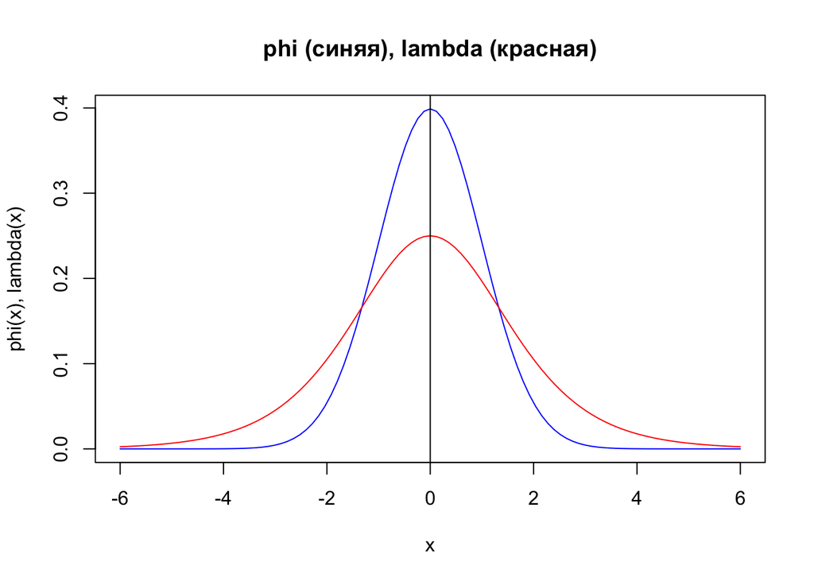

Функции распределения на одном графике

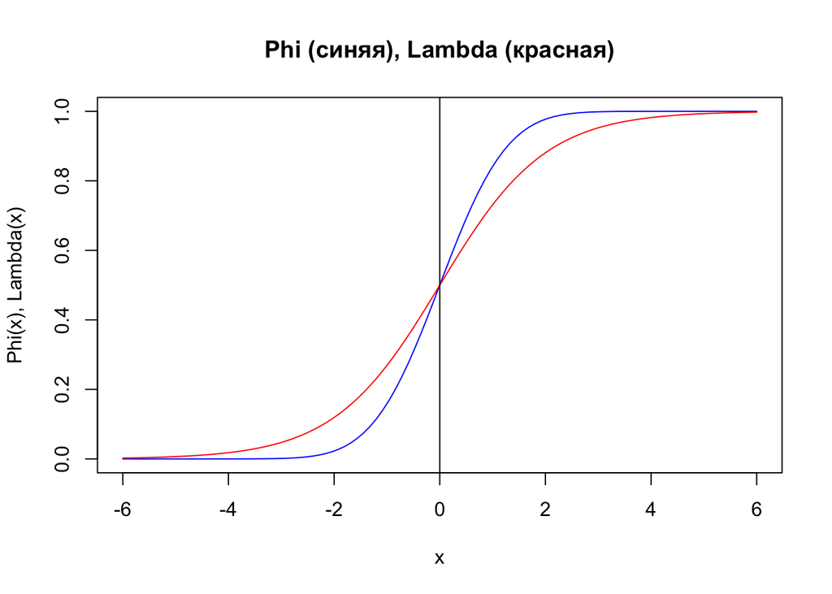

Обратные функции распределение $logit(p)=\Lambda^{-1}(p)=\log\frac{p}{1-p}$ и $probit(p)=\Phi^{-1}(p)$, $0<p<1$

Их графики

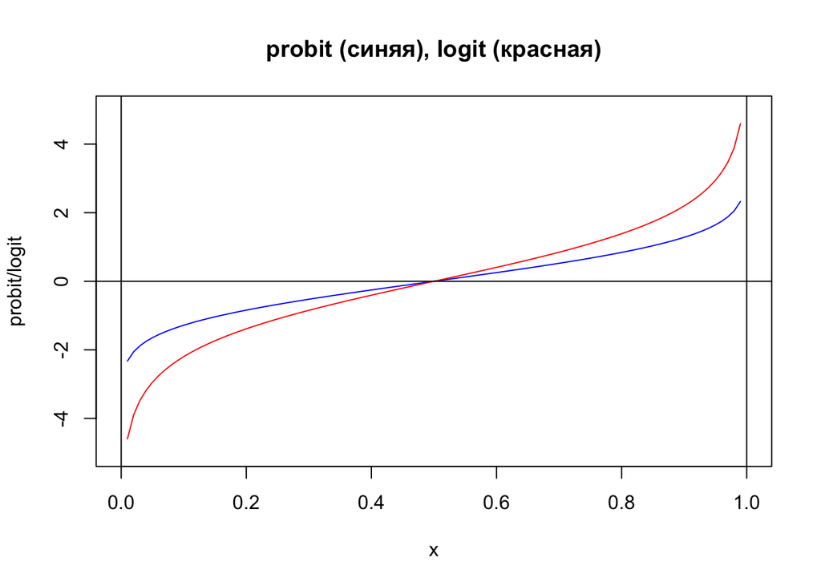

# 2 Интерпретация коэффициентов

## 2.1 approve equation #1 (probit)

Для датасета `loanapp` рассморим probit-регрессию **approve на appinc, mortno, unem, dep, male, married, yjob, self**

Спецификация: $P(approve=1)=\Phi(\beta_0+\beta_1appinc+\beta_2mortno+\beta_3unem+\beta_4dep+\beta_5male+\beta_6married+\beta_7yjob+\beta_8self)$

Альтернативная спецификация: $probit(P(approve=1))=\beta_0+\beta_1appinc+\beta_2mortno+\beta_3unem+\beta_4dep+\beta_5male+\beta_6married+\beta_7yjob+\beta_8self$

Результаты оценивания (коэффициенты):

```
(Intercept)      appinc      mortno        unem         dep        male
      1.142      -0.001       0.407      -0.031      -0.083       0.020
    married        yjob        self
      0.221      -0.001      -0.158
```

**Какая интерпретация?**

## 2.2 approve equation #2 (logit)

Для датасета `loanapp` рассморим logit-регрессию **approve на appinc, mortno, unem, dep, male, married, yjob, self**

Спецификация: $P(approve=1)=\Lambda(\beta_0+\beta_1appinc+\beta_2mortno+\beta_3unem+\beta_4dep+\beta_5male+\beta_6married+\beta_7yjob+\beta_8self)$

Альтернативная спецификация: $logit(P(approve=1))=\beta_0+\beta_1appinc+\beta_2mortno+\beta_3unem+\beta_4dep+\beta_5male+\beta_6married+\beta_7yjob+\beta_8self$

Здесь $logit(P(approve=1))=\log\frac{P(approve=1)}{1-P(approve=1)}=\log\frac{P(approve=1)}{P(approve=0)}$

Результаты оценивания (коэффициенты):

```
(Intercept)      appinc      mortno        unem         dep        male
      1.931      -0.001       0.787      -0.055      -0.161       0.030
    married        yjob        self
      0.425      -0.006      -0.280
```

**Какая интерпретация?**

## 2.3 labour force equation #1 (probit)

Для датасета [mroz_Greene](http://www.stern.nyu.edu/~wgreene/Text/Edition7/TableF5-1.csv) рассморим probit-регрессию **LFP на WA, WA^2, WE, KL6, K618, CIT, UN, log(FAMINC)**

Спецификация: $P(LFP=1)=\Phi(\beta_0+\beta_1WA+\beta_2WA^2+\beta_3WE+\beta_4KL6+\beta_5K618+\beta_5CIT+\beta_7UN+\beta_8\log(FAMINC))$

Альтернативная спецификация: $probit(P(LFP=1))=\beta_0+\beta_1WA+\beta_2WA^2+\beta_3WE+\beta_4KL6+\beta_5K618+\beta_5CIT+\beta_7UN+\beta_8\log(FAMINC)$

Результаты оценивания (коэффициенты):

```
(Intercept)          WA     I(WA^2)          WE         KL6        K618
     -2.005       0.008      -0.001       0.109      -0.851      -0.063
        CIT          UN log(FAMINC)
     -0.128      -0.011       0.200
```

**Какая интерпретация?**

## 2.4 labour force equation #2 (logit)

Для датасета [mroz_Greene](http://www.stern.nyu.edu/~wgreene/Text/Edition7/TableF5-1.csv) рассморим logit-регрессию **LFP на WA, WA^2, WE, KL6, K618, CIT, UN, log(FAMINC)**

Спецификация: $P(LFP=1)=\Lambda(\beta_0+\beta_1WA+\beta_2WA^2+\beta_3WE+\beta_4KL6+\beta_5K618+\beta_5CIT+\beta_7UN+\beta_8\log(FAMINC))$

Альтернативная спецификация: $logit(P(LFP=1))=\beta_0+\beta_1WA+\beta_2WA^2+\beta_3WE+\beta_4KL6+\beta_5K618+\beta_5CIT+\beta_7UN+\beta_8\log(FAMINC)$

Здесь $logit(P(LFP=1))=\log\frac{P(LFP=1)}{1-P(LFP=1)}=\log\frac{P(LFP=1)}{P(LFP=0)}$

Результаты оценивания (коэффициенты):

```
(Intercept)          WA     I(WA^2)          WE         KL6        K618
     -3.241       0.007      -0.001       0.180      -1.414      -0.104
        CIT          UN log(FAMINC)
     -0.217      -0.018       0.333
```

**Какая интерпретация?**

# 3 z-test

## 3.1 approve equation #1 (probit)

Для датасета `loanapp` рассморим probit-регрессию **approve на appinc, mortno, unem, dep, male, married, yjob, self**

Результаты оценивания

```
            Estimate Std. Error
(Intercept)   1.1418     0.1085
appinc       -0.0005     0.0004
mortno        0.4071     0.0869
unem         -0.0308     0.0162
dep          -0.0828     0.0352
male          0.0200     0.0998
married       0.2208     0.0869
yjob         -0.0007     0.0345
self         -0.1583     0.1073
```

Модель была подогнана по 1971 наблюдениям. Уровень значимости 10%

Вычислите z-статистику для каждого коэффициента. **Ответ округлите до 3-х десятичных знаков.**

Ответ

```
(Intercept)      appinc      mortno        unem         dep        male
     10.524      -1.250       4.685      -1.901      -2.352       0.200
    married        yjob        self
      2.541      -0.020      -1.475
```

Вычислите необходимое критическое значение z-теста. **Ответ округлите до 3-х десятичных знаков.**

```
[1] 1.645
```

Какие коэффициенты значимы? Ответ

```
[1] "(Intercept)" "mortno"      "unem"        "dep"         "married"
```

## 3.2 approve equation #2 (logit)

Для датасета `loanapp` рассморим logit-регрессию **approve на appinc, mortno, unem, dep, male, married, yjob, self**

Результаты оценивания

```
z test of coefficients:

               Estimate  Std. Error z value  Pr(>|z|)
(Intercept)  1.93149266  0.19934771  9.6891 < 2.2e-16 ***
appinc      -0.00100204  0.00068086 -1.4717  0.141095
mortno       0.78683422  0.17212256  4.5714 4.846e-06 ***
unem        -0.05494618  0.02944401 -1.8661  0.062024 .
dep         -0.16082637  0.06469036 -2.4861  0.012915 *
male         0.02997238  0.18592688  0.1612  0.871932
married      0.42463227  0.16241191  2.6145  0.008935 **
yjob        -0.00646164  0.06506124 -0.0993  0.920887
self        -0.28039206  0.19666702 -1.4257  0.153949
---
Signif. codes:  0 '***' 0.001 '**' 0.01 '*' 0.05 '.' 0.1 ' ' 1
```

Модель была подогнана по 1971 наблюдениям. Уровень значимости 5%

Вычислите необходимое критическое значение z-теста. **Ответ округлите до 3-х десятичных знаков.**

```
[1] 1.96
```

Какие коэффициенты значимы? Ответ

```
[1] "(Intercept)" "mortno"      "dep"         "married"
```

## 3.3 labour force equation #1 (probit)

Для датасета [mroz_Greene](http://www.stern.nyu.edu/~wgreene/Text/Edition7/TableF5-1.csv) рассморим probit-регрессию **LFP на WA, WA^2, WE, KL6, K618, CIT, UN, log(FAMINC)**

Результаты оценивания

```
z test of coefficients:

               Estimate  Std. Error z value  Pr(>|z|)
(Intercept) -2.00459960  1.70393083 -1.1765   0.23941
WA           0.00761834  0.07009903  0.1087   0.91346
I(WA^2)     -0.00052688  0.00080395 -0.6554   0.51223
WE           0.10876100  0.02409222  4.5144 6.351e-06 ***
KL6         -0.85132886  0.11538984 -7.3778 1.609e-13 ***
K618        -0.06316088  0.04167238 -1.5157   0.12961
CIT         -0.12770910  0.10702987 -1.1932   0.23279
UN          -0.01064433  0.01571953 -0.6771   0.49832
log(FAMINC)  0.19955729  0.10491456  1.9021   0.05716 .
---
Signif. codes:  0 '***' 0.001 '**' 0.01 '*' 0.05 '.' 0.1 ' ' 1
```

Модель была подогнана по 753 наблюдениям. Уровень значимости 10%

Вычислите необходимое критическое значение z-теста. **Ответ округлите до 3-х десятичных знаков.**

```
[1] 1.645
```

Какие коэффициенты значимы? Ответ

```
[1] "WE"          "KL6"         "log(FAMINC)"
```

## 3.4 labour force equation #2 (logit)

Для датасета [mroz_Greene](http://www.stern.nyu.edu/~wgreene/Text/Edition7/TableF5-1.csv) рассморим logit-регрессию **LFP на WA, WA^2, WE, KL6, K618, CIT, UN, log(FAMINC)**

Результаты оценивания

```
            Estimate Std. Error
(Intercept)  -3.2407     2.8337
WA            0.0070     0.1159
I(WA^2)      -0.0008     0.0013
WE            0.1800     0.0404
KL6          -1.4138     0.1987
K618         -0.1042     0.0687
CIT          -0.2165     0.1765
UN           -0.0176     0.0258
log(FAMINC)   0.3331     0.1729
```

Модель была подогнана по 753 наблюдениям. Уровень значимости 5%

Вычислите z-статистику для каждого коэффициента. **Ответ округлите до 3-х десятичных знаков.**

Ответ

```
(Intercept)          WA     I(WA^2)          WE         KL6        K618
     -1.144       0.060      -0.615       4.455      -7.115      -1.517
        CIT          UN log(FAMINC)
     -1.227      -0.682       1.927
```

Вычислите необходимое критическое значение z-теста. **Ответ округлите до 3-х десятичных знаков.**

```
[1] 1.96
```

Какие коэффициенты значимы? Ответ

```
[1] "WE"  "KL6"
```

# 4 LR-тест: значимость регресии

## 4.1 approve equation #1 (probit)

Для датасета `loanapp` рассморим probit-регрессию **approve на appinc, unem, male, yjob, self**

Результаты оценивания

```
MODEL INFO:
Observations: 1974 (15 missing obs. deleted)
Dependent Variable: approve
Type: Generalized linear model
  Family: binomial
  Link function: probit

MODEL FIT:
χ²(5) = 8.5727, p = 0.1274
Pseudo-R² (Cragg-Uhler) = 0.0082
Pseudo-R² (McFadden) = 0.0058
AIC = 1480.1783, BIC = 1513.7052

Standard errors: MLE
-------------------------------------------------------
                       Est.     S.E.    z val.        p
----------------- --------- -------- --------- --------
(Intercept)          1.2548   0.1052   11.9277   0.0000
appinc              -0.0004   0.0004   -0.9528   0.3407
unem                -0.0341   0.0160   -2.1272   0.0334
male                 0.1063   0.0927    1.1462   0.2517
yjob                 0.0059   0.0327    0.1803   0.8569
self                -0.1255   0.1057   -1.1875   0.2350
-------------------------------------------------------
```

Модель была подогнана по 1974 наблюдениям. Логарфим функции правдоподобия для модели $\log L=$-734.0891, для регрессии без объясняющих переменных (только на константу) $\log L_0=$-738.3755

Тестируется значимость регресии, т.е. гипотеза $H_0:\beta_{appinc}=\beta_{unem}=\beta_{male}=\beta_{yjob}=\beta_{self}=0$. Уровень значимости 10%.

Вычислите тестовую статистику. **Ответ округлите до 3-х десятичных знаков.**

Ответ:

```
[1] 8.573
```

Вычислите критическое значение. **Ответ округлите до 3-х десятичных знаков.**

```
[1] 9.236
```

Значима ли регрессия? Ответ

```
[1] "Незначима"
```

Какие коэффициенты значимы?

```
[1] "(Intercept)" "unem"
```

## 4.2 approve equation #2 (logit)

Для датасета `loanapp` рассморим logit-регрессию **approve на appinc, appinc^2, mortno, unem, dep, male, married, yjob, self**

Результаты оценивания

```
MODEL INFO:
Observations: 1971 (18 missing obs. deleted)
Dependent Variable: approve
Type: Generalized linear model
  Family: binomial
  Link function: logit

MODEL FIT:
χ²(9) = 48.4960, p = 0.0000
Pseudo-R² (Cragg-Uhler) = 0.0461
Pseudo-R² (McFadden) = 0.0329
AIC = 1447.4627, BIC = 1503.3256

Standard errors: MLE
-------------------------------------------------------
                       Est.     S.E.    z val.        p
----------------- --------- -------- --------- --------
(Intercept)          1.6806   0.2282    7.3630   0.0000
appinc               0.0042   0.0024    1.7239   0.0847
I(appinc^2)         -0.0000   0.0000   -2.2258   0.0260
mortno               0.7072   0.1750    4.0416   0.0001
unem                -0.0498   0.0296   -1.6852   0.0920
dep                 -0.1545   0.0652   -2.3714   0.0177
male                -0.0207   0.1876   -0.1102   0.9123
married              0.3977   0.1632    2.4376   0.0148
yjob                -0.0101   0.0647   -0.1557   0.8762
self                -0.3593   0.1995   -1.8007   0.0718
-------------------------------------------------------
```

Модель была подогнана по 1971 наблюдениям. Логарфим функции правдоподобия для модели $\log L=$-713.7313, для регрессии без объясняющих переменных (только на константу) $\log L_0=$-737.9793

Тестируется значимость регресии, т.е. гипотеза $H_0:\beta_{appinc}=\beta_{appinc^2}=\beta_{mortno}=\beta_{unem}=\beta_{dep}=\beta_{male}=\beta_{married}=\beta_{yjob}=\beta_{self}=0$. Уровень значимости 5%.

Вычислите тестовую статистику. **Ответ округлите до 3-х десятичных знаков.**

Ответ:

```
[1] 48.496
```

Вычислите критическое значение. **Ответ округлите до 3-х десятичных знаков.**

```
[1] 16.919
```

Значима ли регрессия? Ответ

```
[1] "Значима"
```

Какие коэффициенты значимы?

```
[1] "(Intercept)" "I(appinc^2)" "mortno"      "dep"         "married"
```

## 4.3 labour force equation #1 (probit)

Для датасета [mroz_Greene](http://www.stern.nyu.edu/~wgreene/Text/Edition7/TableF5-1.csv) рассморим несколько probit-регрессй. Результаты оценивания

```
===========================================================
                            Зависимая переменная
                  -----------------------------------------
                                     LFP
                     (1)        (2)        (3)       (4)
-----------------------------------------------------------
WA                  0.0076    0.1084*   0.1297**
                   (0.0701)   (0.0635)  (0.0630)

I(WA2)             -0.0005    -0.0014*  -0.0016**
                   (0.0008)   (0.0007)  (0.0007)

WE                0.1088***
                   (0.0241)

KL6               -0.8513***
                   (0.1154)

K618               -0.0632
                   (0.0417)

CIT                -0.1277    -0.1026    0.0053    -0.0024
                   (0.1070)   (0.1029)  (0.0983)  (0.0975)

UN                 -0.0106    -0.0101    -0.0102   -0.0115
                   (0.0157)   (0.0152)  (0.0151)  (0.0150)

log(FAMINC)        0.1996*   0.3621***
                   (0.1049)   (0.0957)

Constant           -2.0046   -5.2365***  -2.1745   0.2733*
                   (1.7039)   (1.5600)  (1.3281)  (0.1410)

-----------------------------------------------------------
Observations         753        753        753       753
Log Likelihood    -462.3402  -502.2236  -509.6532 -514.5631
Akaike Inf. Crit.  942.6804  1016.4470  1029.3060 1035.1260
===========================================================
Note:                           *p<0.1; **p<0.05; ***p<0.01
```

Логарфим функции правдоподобия для регрессии без объясняющих переменных (только на константу) $\log L_0=$-514.8732.

Для каждой регресси вычислите LR-статистику для тестирования её значимости. **Ответ округлите до 3-х десятичных знаков.**

Ответ

```
=================
Регрессия LR.stat
-----------------
1         105.066
2         25.299
3         10.440
4          0.620
-----------------
```

Для каждой регрессии вычислите необходимое критическое значение Уровень значимости 10%. **Ответ округлите до 3-х десятичных знаков.**

Ответ

```
=====================
Регрессия Критическое
---------------------
1           13.362
2            9.236
3            7.779
4            4.605
---------------------
```

Какая из регрессий значима?

```
====================
Регрессия Значимость
--------------------
1          Значима
2          Значима
3          Значима
4         Незначима
--------------------
```

## 4.4 labour force equation #2 (logit)

Для датасета [mroz_Greene](http://www.stern.nyu.edu/~wgreene/Text/Edition7/TableF5-1.csv) рассморим несколько logit-регрессй. Результаты оценивания

```
============================================================
                             Зависимая переменная
                  ------------------------------------------
                                     LFP
                     (1)        (2)        (3)        (4)
------------------------------------------------------------
WA                  0.0070
                   (0.1159)

I(WA2)             -0.0008
                   (0.0013)

WE                0.1800***  0.2028***
                   (0.0404)   (0.0396)

KL6               -1.4138*** -1.0154*** -0.8645***
                   (0.1987)   (0.1646)   (0.1585)

K618               -0.1042     0.0509     0.0288    -0.0031
                   (0.0687)   (0.0594)   (0.0581)  (0.0558)

CIT                -0.2165    -0.2753    -0.2200    -0.0043
                   (0.1765)   (0.1726)   (0.1691)  (0.1564)

UN                 -0.0176    -0.0287    -0.0196    -0.0185
                   (0.0258)   (0.0254)   (0.0248)  (0.0240)

log(FAMINC)        0.3331*    0.2808*   0.5829***
                   (0.1729)   (0.1683)   (0.1580)

Constant           -3.2407   -4.3882*** -5.0277***  0.4420*
                   (2.8337)   (1.5718)   (1.5542)  (0.2383)

------------------------------------------------------------
Observations         753        753        753        753
Log Likelihood    -462.2363  -475.6736  -489.7908  -514.5605
Akaike Inf. Crit.  942.4726   965.3473   991.5816  1037.1210
============================================================
Note:                            *p<0.1; **p<0.05; ***p<0.01
```

Логарфим функции правдоподобия для регрессии без объясняющих переменных (только на константу) $\log L_0=$-514.8732.

Для каждой регресси вычислите LR-статистику для тестирования её значимости. **Ответ округлите до 3-х десятичных знаков.**

Ответ

```
=================
Регрессия LR.stat
-----------------
1         105.274
2         78.399
3         50.165
4          0.625
-----------------
```

Для каждой регрессии вычислите необходимое критическое значение Уровень значимости 5%. **Ответ округлите до 3-х десятичных знаков.**

Ответ

```
=====================
Регрессия Критическое
---------------------
1           15.507
2           12.592
3           11.070
4            7.815
---------------------
```

Какая из регрессий значима?

```
====================
Регрессия Значимость
--------------------
1          Значима
2          Значима
3          Значима
4         Незначима
--------------------
```

# 5 LR-тест: совместная значимость

## 5.1 labour force equation #1 (probit)

Для датасета [mroz_Greene](http://www.stern.nyu.edu/~wgreene/Text/Edition7/TableF5-1.csv) рассморим несколько probit-регрессй. Результаты оценивания

```
=============================================================
                             Зависимая переменная
                  -------------------------------------------
                                      LFP
                     (1)        (2)        (3)        (4)
-------------------------------------------------------------
WA                  0.0076               -0.0184    -0.0056
                   (0.0701)              (0.0685)   (0.0681)

I(WA2)             -0.0005               -0.0002    -0.0003
                   (0.0008)              (0.0008)   (0.0008)

WE                0.1088***  0.1238***  0.1088***  0.1230***
                   (0.0241)   (0.0237)   (0.0238)   (0.0221)

KL6               -0.8513*** -0.6209*** -0.8473*** -0.8554***
                   (0.1154)   (0.0977)   (0.1149)   (0.1151)

K618               -0.0632     0.0306
                   (0.0417)   (0.0363)

CIT                -0.1277    -0.1654
                   (0.1070)   (0.1053)

UN                 -0.0106    -0.0169
                   (0.0157)   (0.0155)

log(FAMINC)        0.1996*    0.1704*     0.1626
                   (0.1049)   (0.1028)   (0.1016)

Constant           -2.0046   -2.6731***  -1.4351    -0.2815
                   (1.7039)   (0.9574)   (1.6682)   (1.4961)

-------------------------------------------------------------
Observations         753        753        753        753
Log Likelihood    -462.3402  -475.6991  -464.6961  -465.9906
Akaike Inf. Crit.  942.6804   965.3982   941.3922   941.9812
=============================================================
Note:                             *p<0.1; **p<0.05; ***p<0.01
```

Уровень значимости 10%.

### 5.1.1 Гипотеза 1

Для первой модели тестируется значимость влияния возраста, т.е. гипотеза $H_0:\beta_{WA}=\beta_{WA^2}=0$ по LR-тесту.

Вычислите соотвествующую тестовую статистику. **Ответ округлите до 3-х десятичных знаков.**

```
[1] 26.718
```

Вычислите необходимое кртическое значение. **Ответ округлите до 3-х десятичных знаков.**

```
[1] 4.605
```

Значимо ли влияние возраста? Ответ

```
[1] "Значимо"
```

### 5.1.2 Гипотеза 2

Для первой модели тестируется совместная значимость влияния **K618, CIT, UN**, т.е. гипотеза $H_0:\beta_{K618}=\beta_{CIT}=\beta_{UN}=0$ по LR-тесту.

Вычислите соотвествующую тестовую статистику. **Ответ округлите до 3-х десятичных знаков.**

```
[1] 4.712
```

Вычислите необходимое кртическое значение. **Ответ округлите до 3-х десятичных знаков.**

```
[1] 6.251
```

Значимо ли влияние переменных? Ответ

```
[1] "Незначимо"
```

### 5.1.3 Гипотеза 3

Для первой модели тестируется совместная значимость влияния **K618, CIT, UN, FAMINC**, т.е. гипотеза $H_0:\beta_{K618}=\beta_{CIT}=\beta_{UN}=\beta_{\log(FAMINC)}=0$ по LR-тесту.

Вычислите соотвествующую тестовую статистику. **Ответ округлите до 3-х десятичных знаков.**

```
[1] 7.301
```

Вычислите необходимое кртическое значение. **Ответ округлите до 3-х десятичных знаков.**

```
[1] 7.779
```

Значимо ли влияние переменных? Ответ

```
[1] "Незначимо"
```

Для датасета `loanapp` рассморим несколько probit-регрессй. Результаты оценивания

```
===============================================================
                              Зависимая переменная
                  ---------------------------------------------
                                     approve
                      (1)        (2)        (3)         (4)
---------------------------------------------------------------
appinc              0.0022*               0.0018      0.0023*
                   (0.0013)              (0.0012)    (0.0012)

I(appinc2)        -0.000004**           -0.000004** -0.000004**
                  (0.000002)            (0.000002)  (0.000002)

mortno             0.3650***  0.3983***  0.3590***   0.3784***
                   (0.0885)   (0.0866)   (0.0883)    (0.0876)

unem               -0.0280*   -0.0293*   -0.0334**
                   (0.0163)   (0.0162)   (0.0158)

dep                -0.0784**  -0.0861**  -0.0800**    -0.0510
                   (0.0353)   (0.0351)   (0.0352)    (0.0329)

male                -0.0076    0.0143
                   (0.1007)   (0.0997)

married            0.2065**   0.2172**   0.2076**
                   (0.0873)   (0.0869)   (0.0832)

yjob                -0.0039    -0.0010
                   (0.0342)   (0.0345)

self               -0.1961*    -0.1750
                   (0.1088)   (0.1064)

Constant           1.0102***  1.1051***  1.0245***   0.9629***
                   (0.1231)   (0.1048)   (0.1117)    (0.0863)

---------------------------------------------------------------
Observations         1971       1971       1971        1971
Log Likelihood     -713.9286  -717.5349  -715.5429   -720.7842
Akaike Inf. Crit.  1447.8570  1451.0700  1445.0860   1451.5680
===============================================================
Note:                               *p<0.1; **p<0.05; ***p<0.01
```

Уровень значимости 1%.

### 5.2.1 Гипотеза 1

Для первой модели тестируется значимость влияния дохода, т.е. гипотеза $H_0:\beta_{appinc}=\beta_{appinc^2}=0$ по LR-тесту.

Вычислите соотвествующую тестовую статистику. **Ответ округлите до 3-х десятичных знаков.**

```
[1] 7.213
```

Вычислите необходимое кртическое значение. **Ответ округлите до 3-х десятичных знаков.**

```
[1] 9.21
```

```
[1] "Незначимо"
```

### 5.2.2 Гипотеза 2

Для первой модели тестируется совместная значимость влияния **male, yjob, self**, т.е. гипотеза $H_0:\beta_{male}=\beta_{yjob}=\beta_{self}=0$ по LR-тесту.

Вычислите соотвествующую тестовую статистику. **Ответ округлите до 3-х десятичных знаков.**

```
[1] 3.229
```

Вычислите необходимое кртическое значение. **Ответ округлите до 3-х десятичных знаков.**

```
[1] 11.345
```

Значимо ли влияние переменных? Ответ

```
[1] "Незначимо"
```

### 5.2.3 Гипотеза 3

Для первой модели тестируется совместная значимость влияния **male, yjob, self, unem, married**, т.е. гипотеза $H_0:\beta_{male}=\beta_{yjob}=\beta_{self}=\beta_{unem}=\beta_{married}=0$ по LR-тесту

Вычислите соотвествующую тестовую статистику. **Ответ округлите до 3-х десятичных знаков.**

```
[1] 13.711
```

Вычислите необходимое кртическое значение. **Ответ округлите до 3-х десятичных знаков.**

```
[1] 15.086
```

Значимо ли влияние переменных? Ответ

```
[1] "Незначимо"
```

# 6 W-тест: совместная значимость

## 6.1 swiss labour force equation #1

Для датасета `SwissLabour` рассморим logit-регрессию **participation на income, income^2, age, age^2, youngkids, oldkids, foreign**

Результаты оценивания

```
MODEL INFO:
Observations: 872
Dependent Variable: as.numeric(participation) - 1
Type: Generalized linear model
  Family: binomial
  Link function: logit

MODEL FIT:
χ²(7) = 185.1659, p = 0.0000
Pseudo-R² (Cragg-Uhler) = 0.2556
Pseudo-R² (McFadden) = 0.1539
AIC = 1034.0575, BIC = 1072.2238

Standard errors: MLE
-------------------------------------------------------------------
                       Est.      S.E.    z val.        p        VIF
----------------- --------- --------- --------- -------- ----------
(Intercept)         -9.4763   17.2451   -0.5495   0.5827
income               1.8753    3.2660    0.5742   0.5658   276.5677
I(income^2)         -0.1377    0.1552   -0.8875   0.3748   276.4963
age                  3.4025    0.6866    4.9553   0.0000    83.0214
I(age^2)            -0.4846    0.0851   -5.6916   0.0000    83.3744
youngkids           -1.1813    0.1723   -6.8578   0.0000     1.5869
oldkids             -0.2471    0.0843   -2.9321   0.0034     1.4726
foreignyes           1.0728    0.1870    5.7371   0.0000     1.0847
-------------------------------------------------------------------
```

Уровень значимости 5%.

### 6.1.1 Гипотеза 1

Тестируется значимость влияния дохода, т.е. гипотеза $H_0:\beta_{income}=\beta_{income^2}=0$. Результаты W-теста

```
==================
Chisq  Pr(> Chisq)
------------------
24.441   0.00000
------------------
```

Вычислите критическое значение. **Ответ округлите до 3-х десятичных знаков.**

```
[1] 5.991
```

Значимо ли влияние дохода? Ответ

```
[1] "Значимо"
```

### 6.1.2 Гипотеза 2

Тестируется значимость влияния числа детей, т.е. гипотеза $H_0:\beta_{youngkids}=\beta_{oldkids}=0$. Результаты W-теста

```
==================
Chisq  Pr(> Chisq)
------------------
48.420      0
------------------
```

Вычислите критическое значение. **Ответ округлите до 3-х десятичных знаков.**

```
[1] 5.991
```

Значимо ли влияние числе детей? Ответ

```
[1] "Значимо"
```

### 6.1.3 Гипотеза 3

Тестируется значимость влияния возраста, т.е. гипотеза $H_0:\beta_{age}=\beta_{age^2}=0$. Результаты W-теста

```
==================
Chisq  Pr(> Chisq)
------------------
58.911      0
------------------
```

Вычислите критическое значение. **Ответ округлите до 3-х десятичных знаков.**

```
[1] 5.991
```

Значимо ли влияние возраста? Ответ

```
[1] "Значимо"
```